# R Notebook

### Porch Variables

**OpenPorchSF:** Open porch area in square feet.

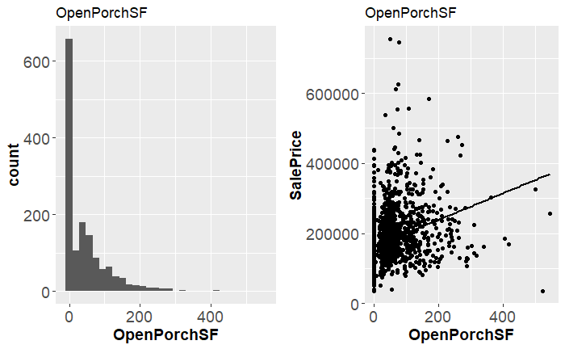

```r
numericggplot("OpenPorchSF")
```

**EnclosedPorch:** Enclosed porch area in square feet.

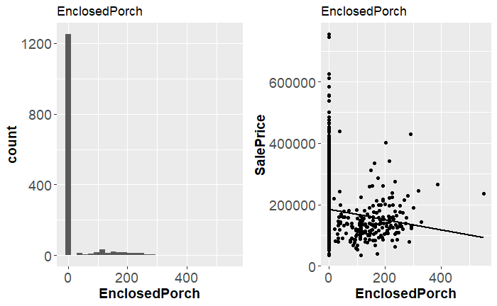

```r
numericggplot("EnclosedPorch")
```

**X3SsnPorch:** Three season porch area in square feet.

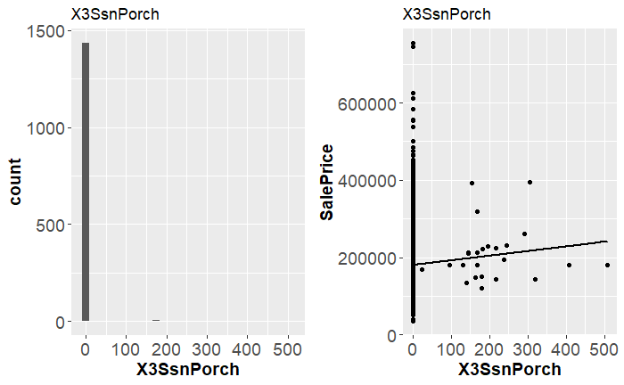

```r
numericggplot("X3SsnPorch")
```

**ScreenPorch:** Screen porch area in square feet.

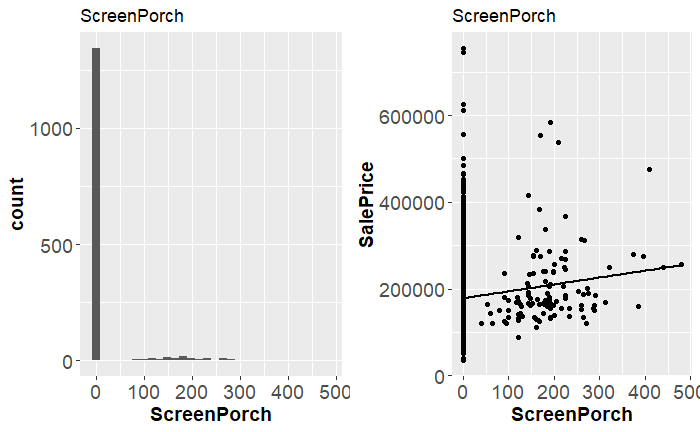

```r
numericggplot("ScreenPorch")
```

A predictor will be made later for whether or not a house has a porch. Most houses have a porch.

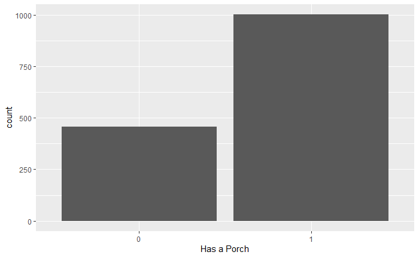

```r
train %>% mutate(hasPorch=ifelse(ScreenPorch>0 | X3SsnPorch>0 | EnclosedPorch>0 | OpenPorchSF>0,1,0)) %>%
  ggplot(.,aes(x=as.factor(hasPorch)))+
  geom_bar()+
  xlab("Has a Porch")
```

Could also add a predictor for the total number of porch square feet.

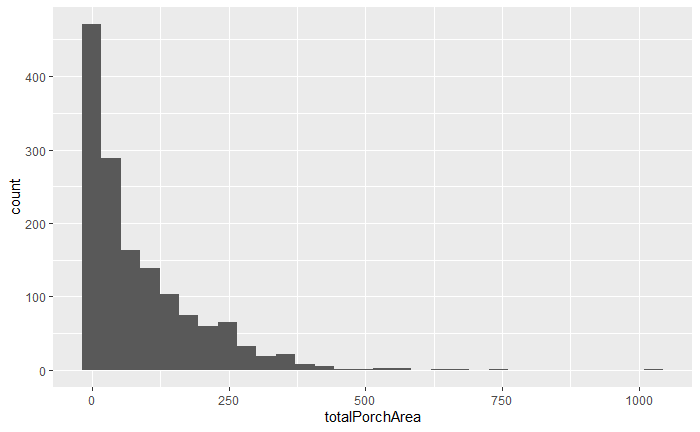

```r
train %>% mutate(totalPorchArea=ScreenPorch+X3SsnPorch+EnclosedPorch+OpenPorchSF) %>%
  ggplot(.,aes(x=totalPorchArea))+
  geom_histogram()
```

**WoodDeckSF:** Wood deck area in square feet.

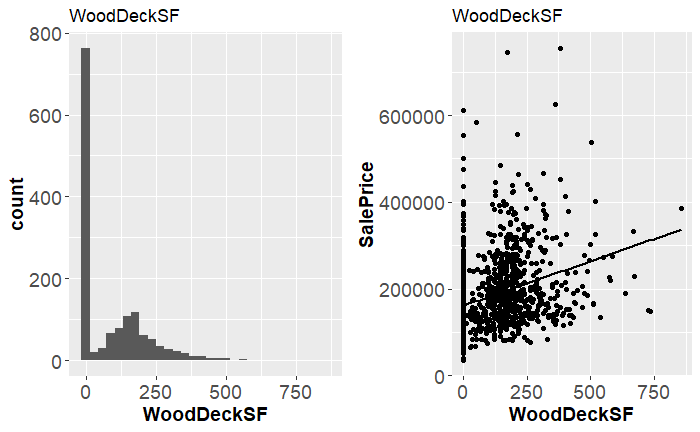

```r
numericggplot("WoodDeckSF")
```

$\textbf{Pick the next tab in order to see other variables.}$

### Pool Area and Quality

**PoolArea:** Pool area in square feet.

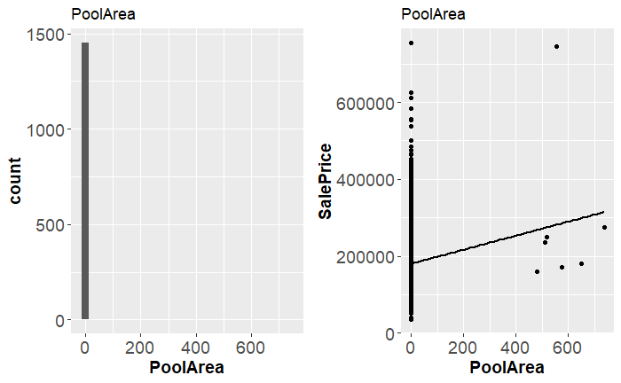

```r
numericggplot("PoolArea")
```

**PoolQC:** Quality of the pool.

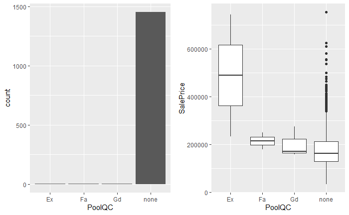

```r
discreteggplot("PoolQC")
```

## Date/Time Predictors

**MoSold:** Month Sold (MM).

Most houses seem to sell in the summer months, but the average house price per month sold seems pretty even.

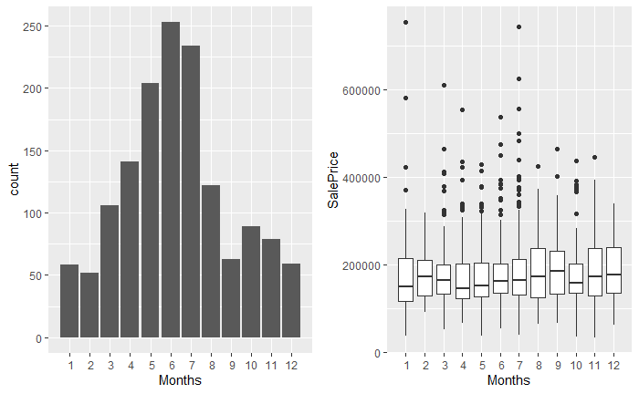

```r
moSold1 <- ggplot(train,aes(x=as.character(MoSold)))+
  geom_bar()+
  scale_x_discrete(limits=seq(1,12))+
  xlab("Months")

moSold2 <- ggplot(train[!is.na(train$SalePrice),],aes(x=as.character(MoSold),y=SalePrice))+
  geom_boxplot()+
  scale_x_discrete(limits=seq(1,12))+
  xlab("Months")

grid.arrange(moSold1,moSold2,ncol=2)
```

```r
NA
```

**YrSold:** Year Sold (YYYY).

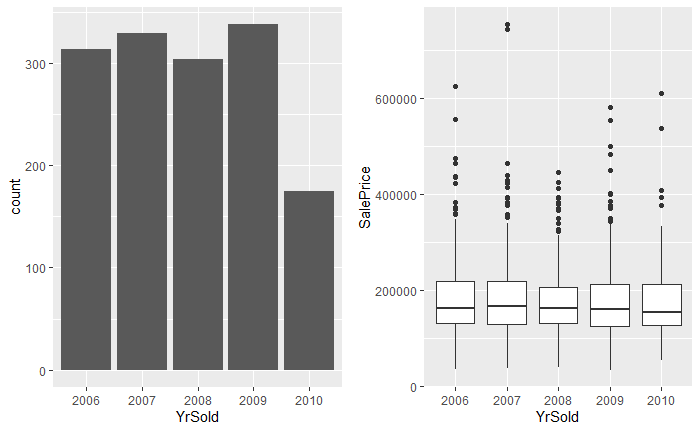

```r
discreteggplot("YrSold")
```

## Ordered Predictors

### Overall Quality

**OverallQual:** Rates the overall material and finish of the house

- 10 Very Excellent
- 9 Excellent
- 8 Very Good
- 7 Good
- 6 Above Average
- 5 Average
- 4 Below Average
- 3 Fair
- 2 Poor
- 1 Very Poor

There is a clear increase in the sale prices as the quality of the house increases.

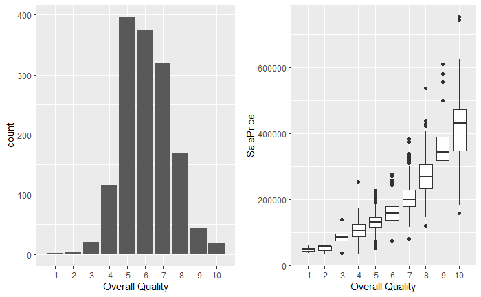

```r
overallqualBar <- ggplot(train,aes(x=OverallQual))+
  geom_bar()+
  scale_x_discrete(limits=seq(1,10))+
  xlab("Overall Quality")

overallqualBox <- ggplot(train,aes(x=as.factor(OverallQual),y=SalePrice))+
  geom_boxplot()+
  scale_x_discrete(limits=seq(1,10))+
  xlab("Overall Quality")

grid.arrange(overallqualBar,overallqualBox,ncol=2)
```

$\textbf{Pick the next tab in order to see other variables.}$

### Overall Condition

**OverallCond:** Rates the overall condition of the house.

- 10 Very Excellent
- 9 Excellent
- 8 Very Good
- 7 Good
- 6 Above Average
- 5 Average
- 4 Below Average
- 3 Fair
- 2 Poor
- 1 Very Poor

There is one outlier for the sale price when the overall condition is 2 and another outlier when the overall condition is 6. These observations are 379 and 692.

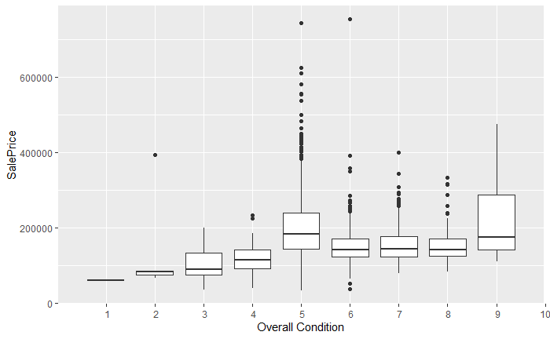

```r
ggplot(train,aes(x=as.character(OverallCond),y=SalePrice))+
  geom_boxplot()+
  scale_x_discrete(limits=seq(1,10))+
  xlab("Overall Condition")
```

```r
kable(train[train$OverallCond==2 & train$SalePrice>350000 & !is.na(train$SalePrice),])
```

|  | Id | MSSubClass | MSZoning | LotFrontage | LotArea | Street | Alley | LotShape | LandContour | Utilities | LotConfig | LandSlope | Neighborhood | Condition1 | Condition2 | BldgType | HouseStyle | OverallQual | OverallCond | YearBuilt | YearRemodAdd | RoofStyle | RoofMatl | Exterior1st | Exterior2nd | MasVnrType | MasVnrArea | ExterQual | ExterCond | … |
| --- | --- | --- | --- | --- | --- | --- | --- | --- | --- | --- | --- | --- | --- | --- | --- | --- | --- | --- | --- | --- | --- | --- | --- | --- | --- | --- | --- | --- | --- | --- |
| 379 | 379 | 20 | RL | 88 | 11394 | Pave | none | Reg | Lvl | AllPub | Corner | Gtl | StoneBr | Norm | Norm | 1Fam | 1Story | 9 | 2 | 2010 | 2010 | Hip | CompShg | VinylSd | VinylSd | Stone | 350 | Gd | TA | … |

```r
kable(train[train$OverallCond==6 & train$SalePrice>600000 & !is.na(train$SalePrice),])
```

|  | Id | MSSubClass | MSZoning | LotFrontage | LotArea | Street | Alley | LotShape | LandContour | Utilities | LotConfig | LandSlope | Neighborhood | Condition1 | Condition2 | BldgType | HouseStyle | OverallQual | OverallCond | YearBuilt | YearRemodAdd | RoofStyle | RoofMatl | Exterior1st | Exterior2nd | MasVnrType | MasVnrArea | ExterQual | ExterCond | … |
| --- | --- | --- | --- | --- | --- | --- | --- | --- | --- | --- | --- | --- | --- | --- | --- | --- | --- | --- | --- | --- | --- | --- | --- | --- | --- | --- | --- | --- | --- | --- |
| 692 | 692 | 60 | RL | 104 | 21535 | Pave | none | IR1 | Lvl | AllPub | Corner | Gtl | NoRidge | Norm | Norm | 1Fam | 2Story | 10 | 6 | 1994 | 1995 | Gable | WdShngl | HdBoard | HdBoard | BrkFace | 1170 | Ex | TA | … |

```r
NA
```

$\textbf{Pick the next tab in order to see other variables.}$

### External Quality and Condition

**ExterQual:** Evaluates the quality of the material on the exterior.

- Ex Excellent
- Gd Good
- TA Average/Typical
- Fa Fair
- Po Poor

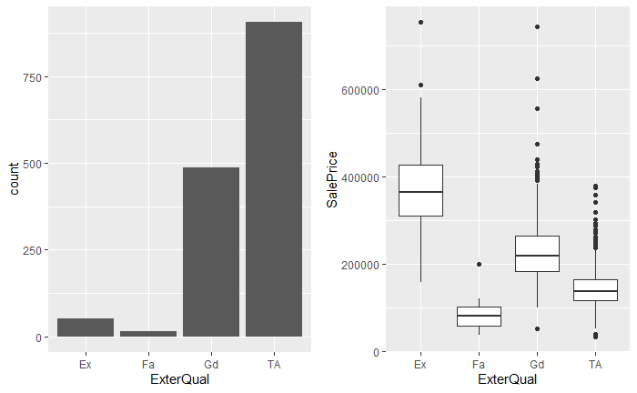

```r
discreteggplot("ExterQual")
```

**ExterCond:** Evaluates the present condition of the material on the exterior. External quality and external condition will both be made into ordered predictors.

- Ex Excellent
- Gd Good
- TA Average/Typical
- Fa Fair
- Po Poor

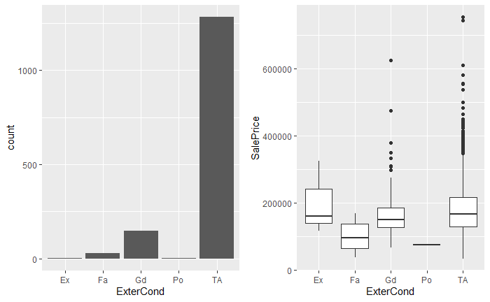

```r
discreteggplot("ExterCond")
```

$\textbf{Pick the next tab in order to see other variables.}$

### Basement Quality and Condition

**BsmtQual:** Evaluates the height of the basement.

- Ex Excellent (100+ inches)
- Gd Good (90-99 inches)
- TA Typical (80-89 inches)
- Fa Fair (70-79 inches)
- Po Poor (<70 inches
- NA No Basement

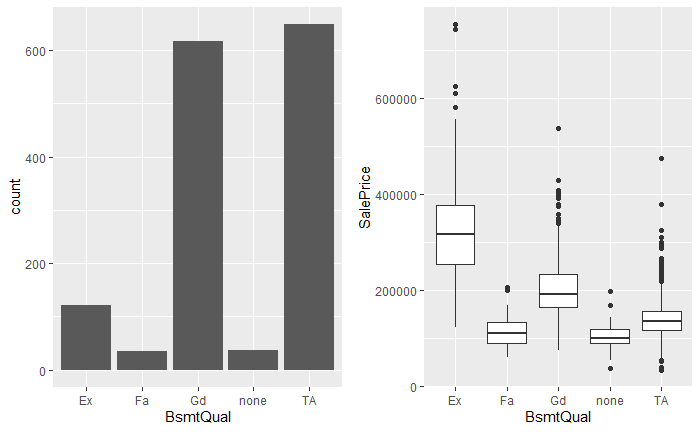

```r
discreteggplot("BsmtQual")
```

**BsmtCond:** Evaluates the general condition of the basement. Both basement quality and basement condition will be made into ordered predictors.

- Ex Excellent
- Gd Good
- TA Typical - slight dampness allowed
- Fa Fair - dampness or some cracking or settling
- Po Poor - Severe cracking, settling, or wetness
- NA No Basement

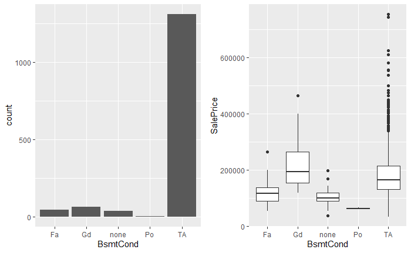

```r
discreteggplot("BsmtCond")
```

$\textbf{Pick the next tab in order to see other variables.}$

### Kitchen Quality

**KitchenQual:** Kitchen quality. Will be made into ordered predictor.

- Ex Excellent
- Gd Good
- TA Typical/Average
- Fa Fair
- Po Poor

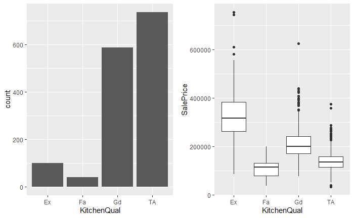

```r
discreteggplot("KitchenQual")
```

$\textbf{Pick the next tab in order to see other variables.}$

### Fireplace Quality

**FireplaceQu:** Fireplace quality.

- Ex Excellent - Exceptional Masonry Fireplace
- Gd Good - Masonry Fireplace in main level
- TA Average - Prefabricated Fireplace in main living area or Masonry Fireplace in basement
- Fa Fair - Prefabricated Fireplace in basement
- Po Poor - Ben Franklin Stove
- NA No Fireplace

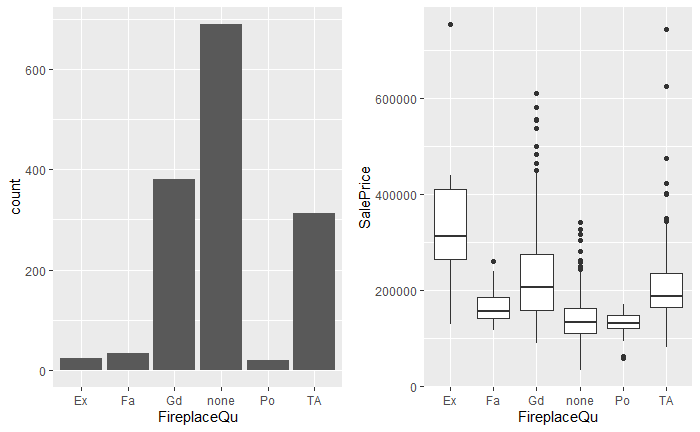

```r
discreteggplot("FireplaceQu")
```

$\textbf{Pick the next tab in order to see other variables.}$

### Garage Quality and Condition

**GarageQual:** Garage quality.

- Ex Excellent
- Gd Good
- TA Typical/Average
- Fa Fair
- Po Poor
- NA No Garage

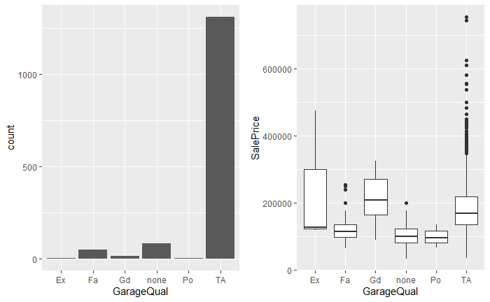

```r
discreteggplot("GarageQual")
```

**GarageCond:** Garage condition. Both garage quality and condition and will be made into ordered predictors.

- Ex Excellent
- Gd Good
- TA Typical/Average
- Fa Fair
- Po Poor
- NA No Garage

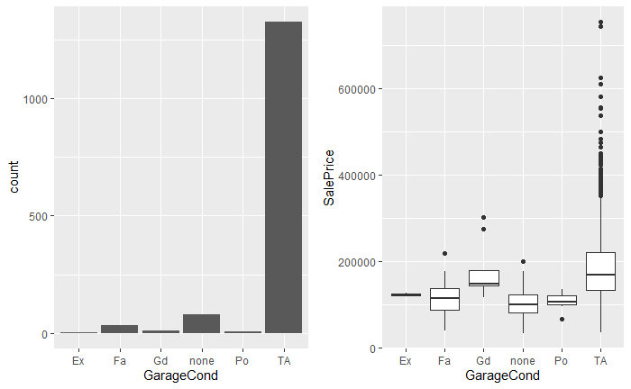

```r
discreteggplot("GarageCond")
```

$\textbf{Pick the next tab in order to see other variables.}$

### Pool Quality

**PoolQC:** Pool quality.

- Ex Excellent
- Gd Good
- TA Average/Typical
- Fa Fair
- NA No Pool

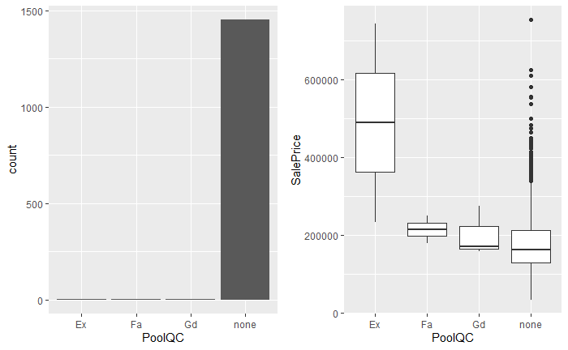

```r
discreteggplot("PoolQC")
```

$\textbf{Pick the next tab in order to see other variables.}$

### Street

**Street:** Type of road access to property.

- Grvl Gravel
- Pave Paved

Can be made into ordered predictor with Paved>Gravel.

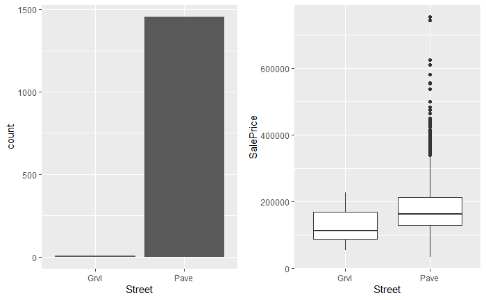

```r
discreteggplot("Street")
```

$\textbf{Pick the next tab in order to see other variables.}$

### LandSlope

**LandSlope:** Slope of property.

- Gtl Gentle slope
- Mod Moderate Slope
- Sev Severe Slope

Made into ordered with Gtl>Mod>Sev.

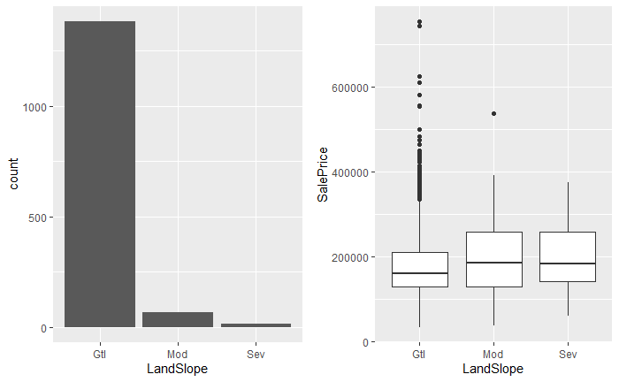

```r
discreteggplot("LandSlope")
```

$\textbf{Pick the next tab in order to see other variables.}$

### Heating quality, Central Air, Electrical

**HeatingQC:** Heating quality and condition.

- Ex Excellent
- Gd Good
- TA Average/Typical
- Fa Fair
- Po Poor

Heating quality, central air, and electrical will all be changed into ordered.

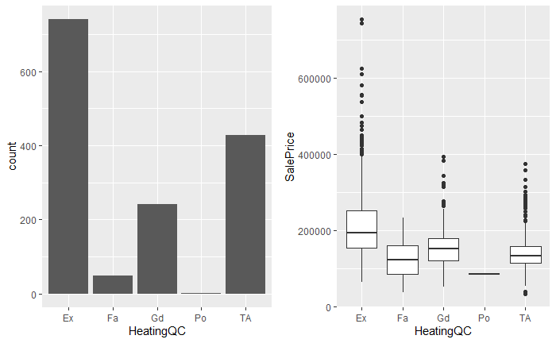

```r
discreteggplot("HeatingQC")
```

**CentralAir:** Central air conditioning.

- N No
- Y Yes

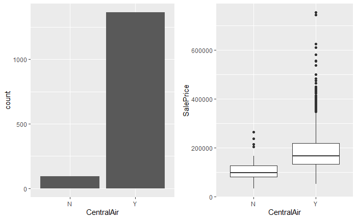

```r
discreteggplot("CentralAir")
```

**Electrical:** Electrical system. Since Electrical is dominated by level of Circuit breaker the NA value will be replaced with this value in the feature engineering section.

- SBrkr Standard Circuit Breakers & Romex
- FuseA Fuse Box over 60 AMP and all Romex wiring (Average)
- FuseF 60 AMP Fuse Box and mostly Romex wiring (Fair)
- FuseP 60 AMP Fuse Box and mostly knob & tube wiring (poor)
- Mix Mixed

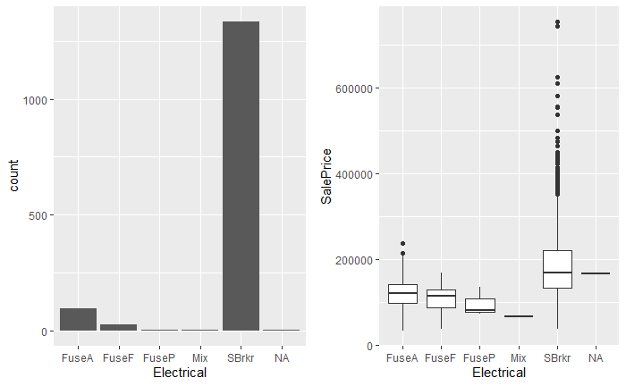

```r
discreteggplot("Electrical")
```

$\textbf{Pick the next tab in order to see other variables.}$

### Masonry Veneer Type

**MasVnrType:** Masonry veneer type.

- BrkCmn Brick Common
- BrkFace Brick Face
- CBlock Cinder Block
- None None
- Stone Stone

Will be made into an ordered predictor with the sequential order of None<Brick Common<Brick Face<Stone. Cinder block is not in the data set so it will not be included, not sure where it would rank.

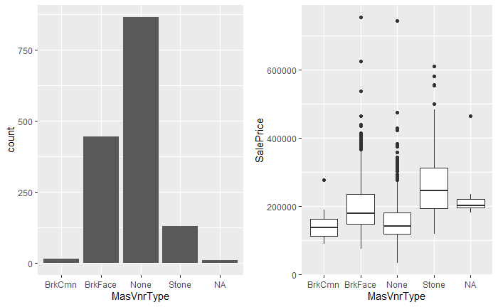

```r
discreteggplot("MasVnrType")
```

$\textbf{Pick the next tab in order to see other variables.}$

### Basement Exposure

**BsmtExposure:** Refers to walkout or garden level walls.

- Gd Good Exposure
- Av Average Exposure (split levels or foyers typically score average or above)
- Mn Mimimum Exposure
- No No Exposure
- NA No Basement

Can be made into ordered based on level of exposure.

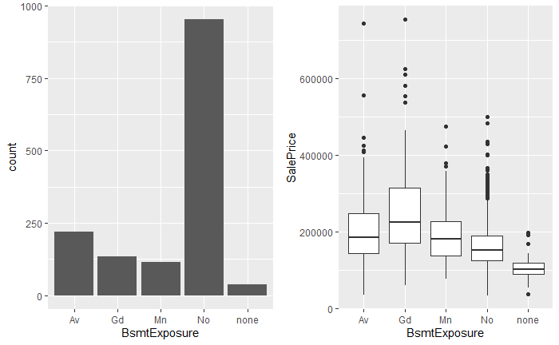

```r
discreteggplot("BsmtExposure")
```

$\textbf{Pick the next tab in order to see other variables.}$

### Garage Finish

**GarageFinish:** Interior finish of the garage.

- Fin Finished
- RFn Rough Finished
- Unf Unfinished
- NA No Garage

Garage finish will be made into ordered.

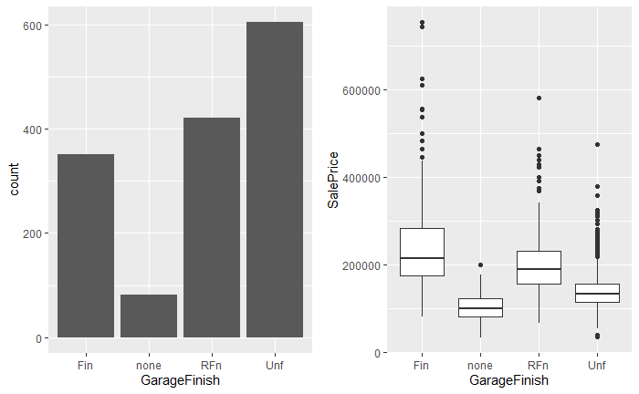

```r
discreteggplot("GarageFinish")
```

$\textbf{Pick the next tab in order to see other variables.}$

### Paved Drive

**PavedDrive:** Paved driveway.

- Y Paved
- P Partial Pavement
- N Dirt/Gravel

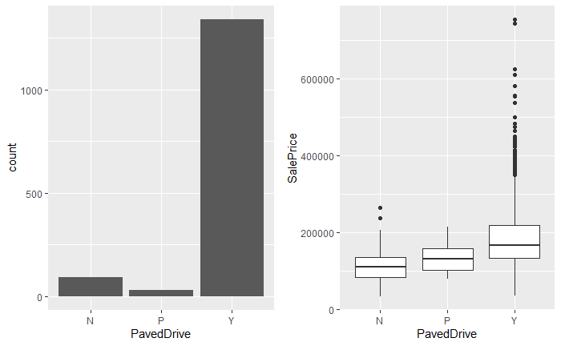

```r
discreteggplot("PavedDrive")
```

$\textbf{Pick the next tab in order to see other variables.}$

### Fence

**Fence:** Fence quality.

- GdPrv Good Privacy
- MnPrv Minimum Privacy
- GdWo Good Wood
- MnWw Minimum Wood/Wire
- NA No Fence

It appears having no fence translates to a higher sales price than having a fence. Will convert this predictor to ordered with having no fence having the highest median sales price.

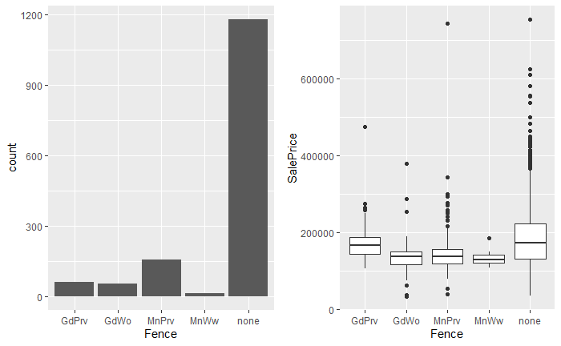

```r
discreteggplot("Fence")
```

## Categorical Predictors

### MSSubClass

**MSSubClass:** Identifies the type of dwelling involved in the sale.

- 20 1-STORY 1946 & NEWER ALL STYLES
- 30 1-STORY 1945 & OLDER
- 40 1-STORY W/FINISHED ATTIC ALL AGES
- 45 1-1/2 STORY - UNFINISHED ALL AGES
- 50 1-1/2 STORY FINISHED ALL AGES
- etc (11 more labels)

The type of dwelling is currently a numeric predictor, it should be a factor.

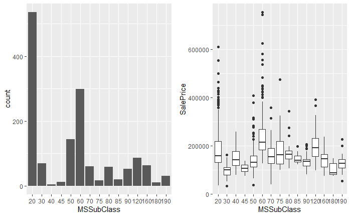

```r
discreteggplot("MSSubClass")
```

$\textbf{Pick the next tab in order to see other variables.}$

### MSZoning

**MSZoning:** Identifies the general zoning classification of the sale.

- A Agriculture
- C Commercial
- FV Floating Village Residential
- I Industrial
- RH Residential High Density
- RL Residential Low Density
- RP Residential Low Density Park
- RM Residential Medium Density

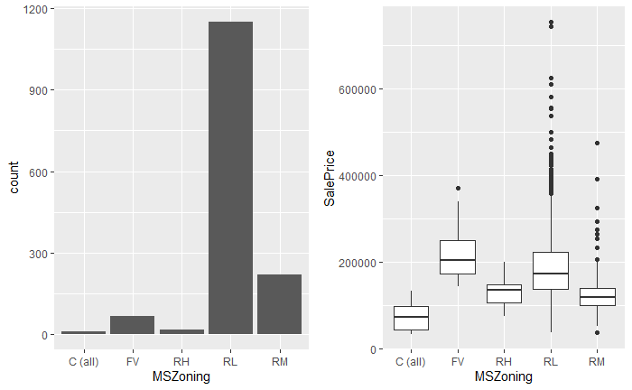

```r
discreteggplot("MSZoning")
```

$\textbf{Pick the next tab in order to see other variables.}$

### Alley

Alley: Type of alley access to property.

- Grvl Gravel
- Pave Paved
- NA No alley access

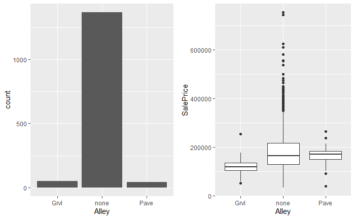

```r
discreteggplot("Alley")
```

$\textbf{Pick the next tab in order to see other variables.}$

### Lotshape

**LotShape:** General shape of property.

- Reg Regular
- IR1 Slightly irregular
- IR2 Moderately Irregular
- IR3 Irregular

Could be an ordered predictor, box-plot doesn’t support this claim though so leaving as character.

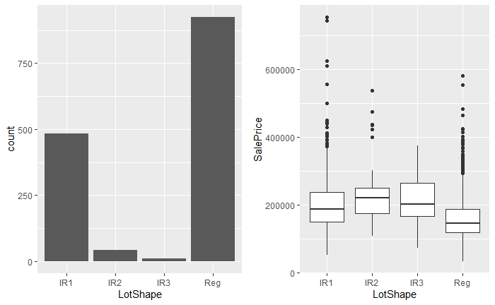

```r
discreteggplot("LotShape")
```

$\textbf{Pick the next tab in order to see other variables.}$

### Land Contour

**LandContour:** Flatness of the property.

- Lvl Near Flat/Level
- Bnk Banked - Quick and significant rise from street grade to building
- HLS Hillside - Significant slope from side to side
- Low Depression

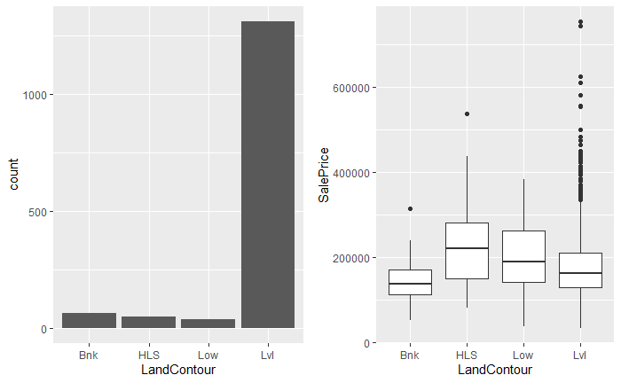

```r
discreteggplot("LandContour")
```

$\textbf{Pick the next tab in order to see other variables.}$

### Lot Config.

**LotConfig:** Lot configuration.

- Inside Inside lot
- Corner Corner lot
- CulDSac Cul-de-sac
- FR2 Frontage on 2 sides of property
- FR3 Frontage on 3 sides of property

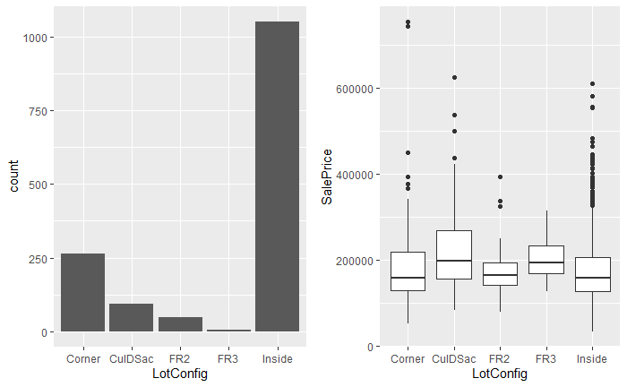

```r
discreteggplot("LotConfig")
```

$\textbf{Pick the next tab in order to see other variables.}$

### Neighborhood

**Neighborhood:** Physical locations within Ames city limits.

- Blmngtn Bloomington Heights
- Blueste Bluestem
- BrDale Briardale
- BrkSide Brookside
- etc (21 other labels)

There exists twenty-five possible labels for neighborhood.

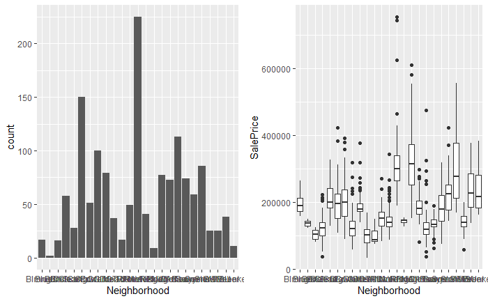

```r
discreteggplot("Neighborhood")
```

```r
train %>% group_by(Neighborhood) %>% summarize(count=n(),avgSalePrice=mean(SalePrice)) %>% arrange(desc(count))
```

| Neighborhood | count | avgSalePrice |
| --- | --- | --- |
| NAmes | 225 | 145847.08 |
| CollgCr | 150 | 197965.77 |
| OldTown | 113 | 128225.30 |
| Edwards | 100 | 128219.70 |
| Somerst | 86 | 225379.84 |
| Gilbert | 79 | 192854.51 |
| NridgHt | 77 | 316270.62 |
| Sawyer | 74 | 136793.14 |
| NWAmes | 73 | 189050.07 |
| SawyerW | 59 | 186555.80 |

[output cut: 15 more lines]

$\textbf{Pick the next tab in order to see other variables.}$

### Condition1 and Condition2

**Condition1:** Proximity to various conditions.

- Artery Adjacent to arterial street
- Feedr Adjacent to feeder street
- Norm Normal
- RRNn Within 200’ of North-South Railroad
- RRAn Adjacent to North-South Railroad
- PosN Near positive off-site feature–park, greenbelt, etc.
- PosA Adjacent to postive off-site feature
- RRNe Within 200’ of East-West Railroad
- RRAe Adjacent to East-West Railroad

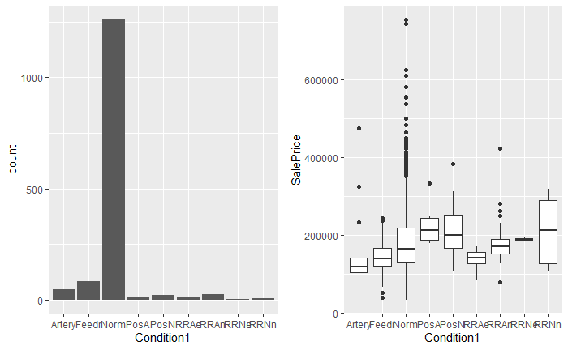

```r
discreteggplot("Condition1")
```

```r
table(train$Condition1)
```

```
Artery  Feedr   Norm   PosA   PosN   RRAe   RRAn   RRNe   RRNn
    48     81   1260      8     19     11     26      2      5
```

**Condition2:** Proximity to various conditions (if more than one is present).

- Artery Adjacent to arterial street
- Feedr Adjacent to feeder street
- Norm Normal
- RRNn Within 200’ of North-South Railroad
- RRAn Adjacent to North-South Railroad
- PosN Near positive off-site feature–park, greenbelt, etc.
- PosA Adjacent to postive off-site feature
- RRNe Within 200’ of East-West Railroad
- RRAe Adjacent to East-West Railroad

87% of the houses have the same condition1 and condition2 value, one of the columns will likely be dropped.

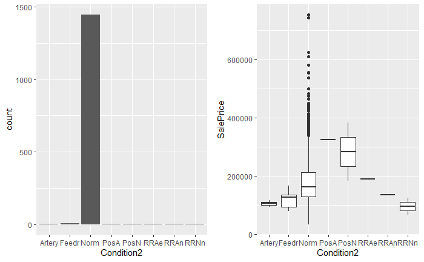

```r
discreteggplot("Condition2")
```

```r
round(sum((train$Condition1==train$Condition2)/nrow(train)),2)
```

```
[1] 0.87
```

$\textbf{Pick the next tab in order to see other variables.}$

### Building Type and House Style

**BldgType:** Type of dwelling.

- 1Fam Single-family Detached
- 2FmCon Two-family Conversion; originally built as one-family dwelling
- Duplx Duplex
- TwnhsE Townhouse End Unit
- TwnhsI Townhouse Inside Unit

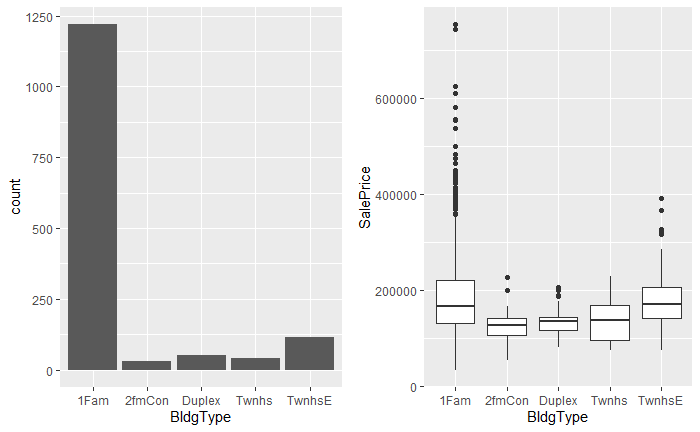

```r
discreteggplot("BldgType")
```

**HouseStyle:** Style of dwelling.

- 1Story One story
- 1.5Fin One and one-half story: 2nd level finished
- 1.5Unf One and one-half story: 2nd level unfinished
- 2Story Two story
- 2.5Fin Two and one-half story: 2nd level finished
- 2.5Unf Two and one-half story: 2nd level unfinished
- SFoyer Split Foyer
- SLvl Split Level

House Style has some rare labels that may require grouping.

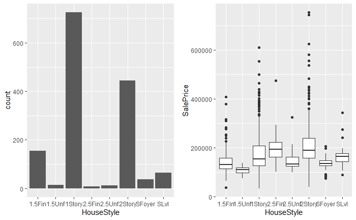

```r
discreteggplot("HouseStyle")
```

$\textbf{Pick the next tab in order to see other variables.}$

### Roof Style and Material

**RoofStyle:** Type of roof.

- Flat Flat
- Gable Gable
- Gambrel Gabrel (Barn)
- Hip Hip
- Mansard Mansard
- Shed Shed

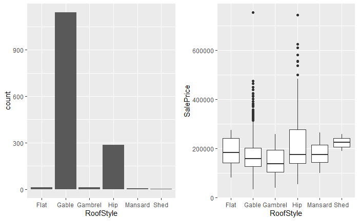

```r
discreteggplot("RoofStyle")
```

**RoofMatl:** Roof material.

- ClyTile Clay or Tile
- CompShg Standard (Composite) Shingle
- Membran Membrane
- Metal Metal
- Roll Roll
- Tar&Grv Gravel & Tar
- WdShake Wood Shakes
- WdShngl Wood Shingles

Roof material has four levels that only occur once. These levels will either need to be dropped or grouped.

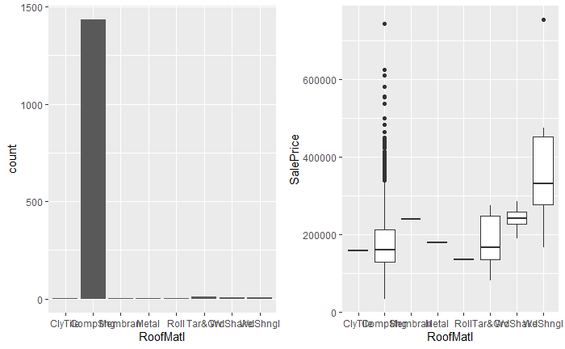

```r
discreteggplot("RoofMatl")
```

```r
table(train$RoofMatl)
```

```
ClyTile CompShg Membran   Metal    Roll Tar&Grv WdShake WdShngl
      1    1434       1       1       1      11       5       6
```

$\textbf{Pick the next tab in order to see other variables.}$

### Exterior1st and 2nd

**Exterior1st:** Exterior covering on house.

- AsbShng Asbestos Shingles
- AsphShn Asphalt Shingles
- BrkComm Brick Common
- BrkFace Brick Face
- CBlock Cinder Block
- etc (12 other levels)

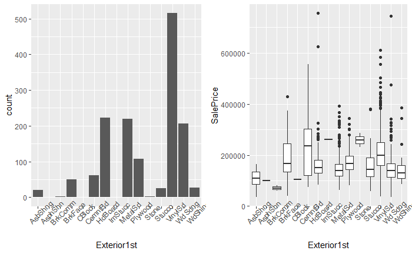

```r
exterior1stBar <- ggplot(train,aes(x=Exterior1st))+
  geom_bar()+
  theme(axis.text.x = element_text(angle = 45))


exterior1stBox <- ggplot(train[!is.na(train$SalePrice),],aes(x=Exterior1st,y=SalePrice))+
  geom_boxplot()+
  theme(axis.text.x = element_text(angle = 45))

grid.arrange(exterior1stBar,exterior1stBox, ncol=2)
```

**Exterior2nd:** Exterior covering on house (if more than one material).

- AsbShng Asbestos Shingles
- AsphShn Asphalt Shingles
- BrkComm Brick Common
- BrkFace Brick Face
- CBlock Cinder Block
- etc (12 other levels)

Most of the time exterior1st is the same as exterior2nd, one of the predictors will likely be dropped.

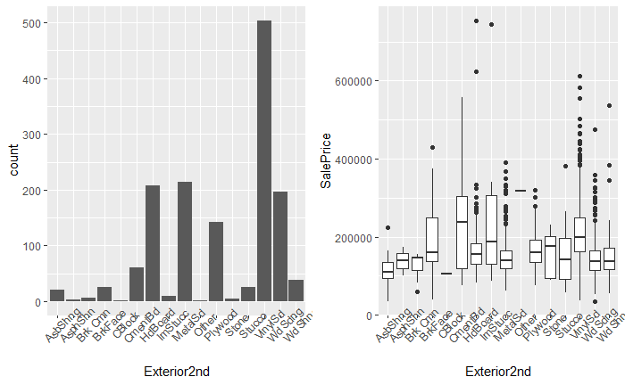

```r
exterior2ndBar <- ggplot(train,aes(x=Exterior2nd))+
  geom_bar()+
  theme(axis.text.x = element_text(angle = 45))


exterior2ndBox <- ggplot(train[!is.na(train$SalePrice),],aes(x=Exterior2nd,y=SalePrice))+
  geom_boxplot()+
  theme(axis.text.x = element_text(angle = 45))

grid.arrange(exterior2ndBar,exterior2ndBox, ncol=2)
```

```r
round(sum(train$Exterior1st==train$Exterior2nd)/nrow(train),2)
```

```
[1] 0.85
```

$\textbf{Pick the next tab in order to see other variables.}$

### Foundation

**Foundation:** Type of foundation.

- BrkTil Brick & Tile
- CBlock Cinder Block
- PConc Poured Contrete
- Slab Slab
- Stone Stone
- Wood Wood

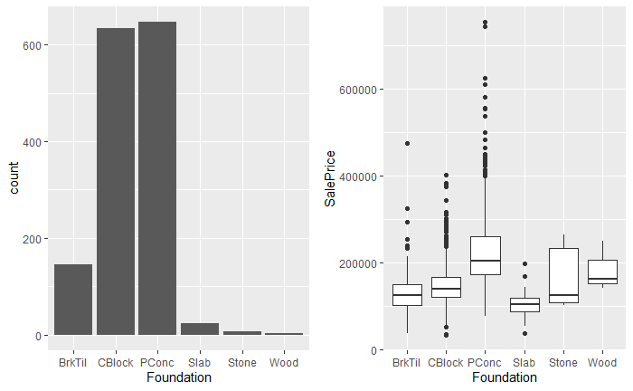

```r
discreteggplot("Foundation")
```

$\textbf{Pick the next tab in order to see other variables.}$

### BsmtFinType 1 and 2

**BsmtFinType1:** Rating of basement finished area.

- GLQ Good Living Quarters
- ALQ Average Living Quarters
- BLQ Below Average Living Quarters
- Rec Average Rec Room
- LwQ Low Quality
- Unf Unfinshed
- NA No Basement

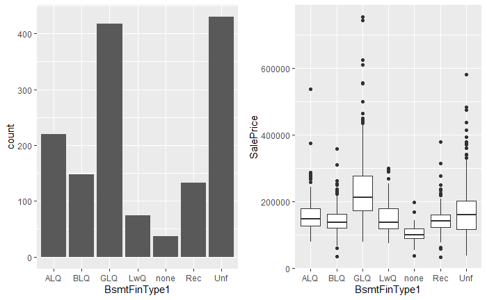

```r
discreteggplot("BsmtFinType1")
```

**BsmtFinType2:** Rating of basement finished area (if multiple types).

- GLQ Good Living Quarters
- ALQ Average Living Quarters
- BLQ Below Average Living Quarters
- Rec Average Rec Room
- LwQ Low Quality
- Unf Unfinished
- NA No Basement

From the plots it is shown that the sale price did not increase as would be expected when moving from no basement to good living quarters. Because of this, these two predictors will remain character instead of being made into ordered. Almost all of basement finish type2 are of the unfinished class.

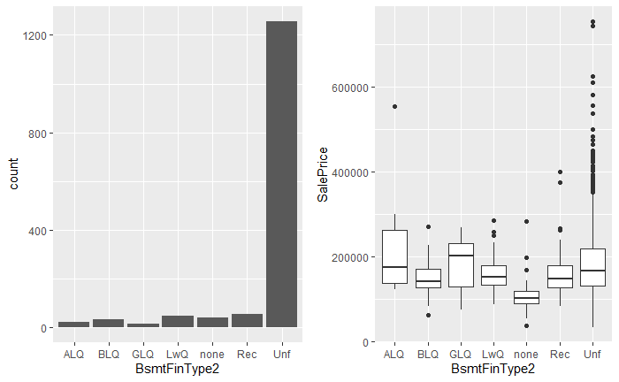

```r
discreteggplot("BsmtFinType2")
```

$\textbf{Pick the next tab in order to see other variables.}$

### Heating

**Heating:** Type of heating.

- Floor Floor Furnace
- GasA Gas forced warm air furnace
- GasW Gas hot water or steam heat
- Grav Gravity furnace
- OthW Hot water or steam heat other than gas
- Wall Wall furnace

Nearly all houses have gas forced heating.

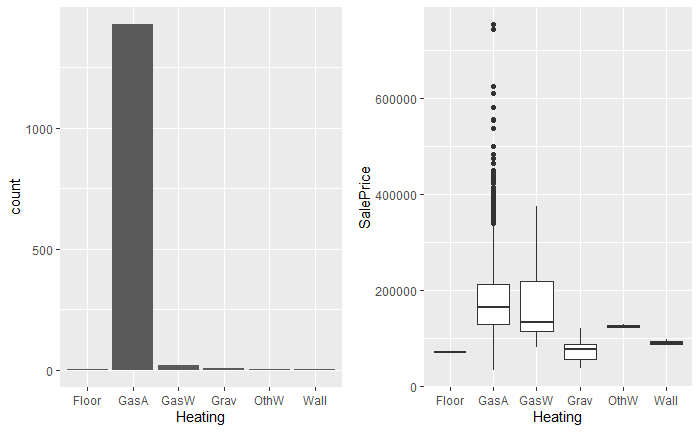

```r
discreteggplot("Heating")
```

```r
table(train$Heating)
```

```
Floor  GasA  GasW  Grav  OthW  Wall
    1  1428    18     7     2     4
```

$\textbf{Pick the next tab in order to see other variables.}$

### Functional

**Functional:** Home functionality (Assume typical unless deductions are warranted).

- Typ Typical Functionality
- Min1 Minor Deductions 1
- Min2 Minor Deductions 2
- Mod Moderate Deductions
- Maj1 Major Deductions 1
- Maj2 Major Deductions 2
- Sev Severely Damaged
- Sal Salvage only

Nearly all values are typical.

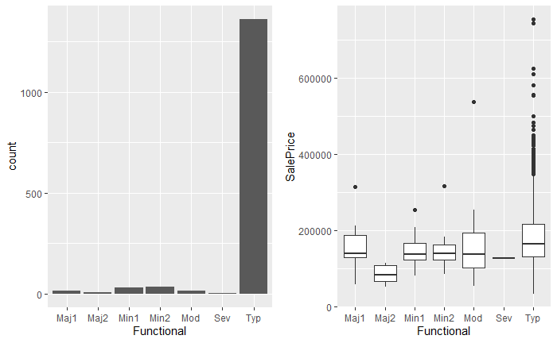

```r
discreteggplot("Functional")
```

$\textbf{Pick the next tab in order to see other variables.}$

### Garage Type

**GarageType:** Garage location.

- 2Types More than one type of garage
- Attchd Attached to home
- Basment Basement Garage
- BuiltIn Built-In (Garage part of house - typically has room above garage)
- CarPort Car Port
- Detchd Detached from home
- NA No Garage

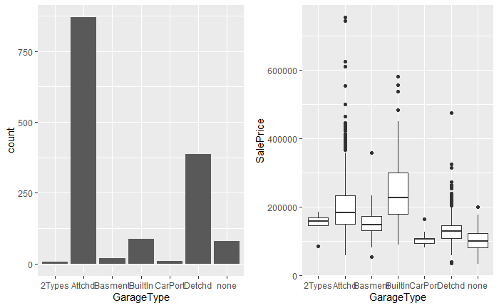

```r
discreteggplot("GarageType")
```

$\textbf{Pick the next tab in order to see other variables.}$

### Misc Feature

**MiscFeature:** Miscellaneous feature not covered in other categories.

- Elev Elevator
- Gar2 2nd Garage (if not described in garage section)
- Othr Other
- Shed Shed (over 100 SF)
- TenC Tennis Court
- NA None

96% of houses do not have a miscellaneous feature.

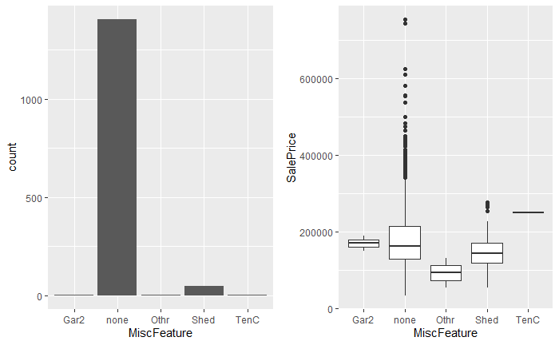

```r
discreteggplot("MiscFeature")
```

```r
round(sum(train$MiscFeature=="none")/nrow(train),2)
```

```
[1] 0.96
```

$\textbf{Pick the next tab in order to see other variables.}$